# Risk Factor Analysis

## Outcome Variable

**Outcome Variable:** stunted

## Predictor Variables

**Intervention Variable:** month

**Adjustment Set:**

unadjusted

## Stratifying Variables

The analysis was stratified on these variable(s):

- agecat
- studyid
- country

## Data Summary

| agecat | studyid | country | A | n | nA | nAY0 | nAY1 |
| --- | --- | --- | --- | --- | --- | --- | --- |
| Birth | ki0047075b-MAL-ED | BANGLADESH | 1 | 257 | 19 | 16 | 3 |
| Birth | ki0047075b-MAL-ED | BANGLADESH | 2 | 257 | 24 | 18 | 6 |
| Birth | ki0047075b-MAL-ED | BANGLADESH | 3 | 257 | 28 | 20 | 8 |
| Birth | ki0047075b-MAL-ED | BANGLADESH | 4 | 257 | 21 | 21 | 0 |
| Birth | ki0047075b-MAL-ED | BANGLADESH | 5 | 257 | 21 | 16 | 5 |
| Birth | ki0047075b-MAL-ED | BANGLADESH | 6 | 257 | 9 | 5 | 4 |
| Birth | ki0047075b-MAL-ED | BANGLADESH | 7 | 257 | 22 | 17 | 5 |
| Birth | ki0047075b-MAL-ED | BANGLADESH | 8 | 257 | 25 | 20 | 5 |
| Birth | ki0047075b-MAL-ED | BANGLADESH | 9 | 257 | 22 | 20 | 2 |
| Birth | ki0047075b-MAL-ED | BANGLADESH | 10 | 257 | 24 | 19 | 5 |
| Birth | ki0047075b-MAL-ED | BANGLADESH | 11 | 257 | 15 | 13 | 2 |
| Birth | ki0047075b-MAL-ED | BANGLADESH | 12 | 257 | 27 | 25 | 2 |
| Birth | ki0047075b-MAL-ED | BRAZIL | 1 | 191 | 9 | 9 | 0 |
| Birth | ki0047075b-MAL-ED | BRAZIL | 2 | 191 | 21 | 18 | 3 |
| Birth | ki0047075b-MAL-ED | BRAZIL | 3 | 191 | 18 | 17 | 1 |
| Birth | ki0047075b-MAL-ED | BRAZIL | 4 | 191 | 8 | 8 | 0 |
| Birth | ki0047075b-MAL-ED | BRAZIL | 5 | 191 | 19 | 16 | 3 |
| Birth | ki0047075b-MAL-ED | BRAZIL | 6 | 191 | 7 | 6 | 1 |
| Birth | ki0047075b-MAL-ED | BRAZIL | 7 | 191 | 17 | 13 | 4 |
| Birth | ki0047075b-MAL-ED | BRAZIL | 8 | 191 | 18 | 16 | 2 |
| Birth | ki0047075b-MAL-ED | BRAZIL | 9 | 191 | 28 | 24 | 4 |
| Birth | ki0047075b-MAL-ED | BRAZIL | 10 | 191 | 18 | 18 | 0 |
| Birth | ki0047075b-MAL-ED | BRAZIL | 11 | 191 | 15 | 15 | 0 |
| Birth | ki0047075b-MAL-ED | BRAZIL | 12 | 191 | 13 | 10 | 3 |
| Birth | ki0047075b-MAL-ED | INDIA | 1 | 206 | 16 | 15 | 1 |
| Birth | ki0047075b-MAL-ED | INDIA | 2 | 206 | 16 | 16 | 0 |
| Birth | ki0047075b-MAL-ED | INDIA | 3 | 206 | 20 | 18 | 2 |
| Birth | ki0047075b-MAL-ED | INDIA | 4 | 206 | 15 | 13 | 2 |
| Birth | ki0047075b-MAL-ED | INDIA | 5 | 206 | 7 | 6 | 1 |
| Birth | ki0047075b-MAL-ED | INDIA | 6 | 206 | 17 | 16 | 1 |

[output cut: 2070 more lines]

The following strata were considered:

- agecat: 12 months, studyid: ki0047075b-MAL-ED, country: BANGLADESH
- agecat: 12 months, studyid: ki0047075b-MAL-ED, country: BRAZIL
- agecat: 12 months, studyid: ki0047075b-MAL-ED, country: INDIA
- agecat: 12 months, studyid: ki0047075b-MAL-ED, country: NEPAL
- agecat: 12 months, studyid: ki0047075b-MAL-ED, country: PERU
- agecat: 12 months, studyid: ki0047075b-MAL-ED, country: SOUTH AFRICA
- agecat: 12 months, studyid: ki0047075b-MAL-ED, country: TANZANIA, UNITED REPUBLIC OF
- agecat: 12 months, studyid: ki1000108-CMC-V-BCS-2002, country: INDIA
- agecat: 12 months, studyid: ki1000108-IRC, country: INDIA
- agecat: 12 months, studyid: ki1000109-EE, country: PAKISTAN
- agecat: 12 months, studyid: ki1000109-ResPak, country: PAKISTAN
- agecat: 12 months, studyid: ki1000304b-SAS-CompFeed, country: INDIA
- agecat: 12 months, studyid: ki1000304b-SAS-FoodSuppl, country: INDIA
- agecat: 12 months, studyid: ki1017093-NIH-Birth, country: BANGLADESH
- agecat: 12 months, studyid: ki1066203-TanzaniaChild2, country: TANZANIA, UNITED REPUBLIC OF
- agecat: 12 months, studyid: ki1112895-Guatemala BSC, country: GUATEMALA
- agecat: 12 months, studyid: ki1113344-GMS-Nepal, country: NEPAL
- agecat: 12 months, studyid: ki1114097-CMIN, country: BANGLADESH
- agecat: 12 months, studyid: ki1114097-CMIN, country: BRAZIL
- agecat: 12 months, studyid: ki1114097-CMIN, country: GUINEA-BISSAU
- agecat: 12 months, studyid: ki1114097-CMIN, country: PERU
- agecat: 12 months, studyid: ki1114097-CONTENT, country: PERU
- agecat: 12 months, studyid: ki1119695-PROBIT, country: BELARUS
- agecat: 12 months, studyid: ki1126311-ZVITAMBO, country: ZIMBABWE
- agecat: 12 months, studyid: ki1148112-LCNI-5, country: MALAWI
- agecat: 12 months, studyid: kiGH5241-JiVitA-3, country: BANGLADESH
- agecat: 12 months, studyid: kiGH5241-JiVitA-4, country: BANGLADESH
- agecat: 18 months, studyid: ki0047075b-MAL-ED, country: BANGLADESH
- agecat: 18 months, studyid: ki0047075b-MAL-ED, country: BRAZIL
- agecat: 18 months, studyid: ki0047075b-MAL-ED, country: INDIA
- agecat: 18 months, studyid: ki0047075b-MAL-ED, country: NEPAL
- agecat: 18 months, studyid: ki0047075b-MAL-ED, country: PERU
- agecat: 18 months, studyid: ki0047075b-MAL-ED, country: SOUTH AFRICA
- agecat: 18 months, studyid: ki0047075b-MAL-ED, country: TANZANIA, UNITED REPUBLIC OF
- agecat: 18 months, studyid: ki1000108-CMC-V-BCS-2002, country: INDIA
- agecat: 18 months, studyid: ki1000108-IRC, country: INDIA
- agecat: 18 months, studyid: ki1000109-EE, country: PAKISTAN
- agecat: 18 months, studyid: ki1000109-ResPak, country: PAKISTAN
- agecat: 18 months, studyid: ki1000304b-SAS-CompFeed, country: INDIA
- agecat: 18 months, studyid: ki1000304b-SAS-FoodSuppl, country: INDIA
- agecat: 18 months, studyid: ki1017093-NIH-Birth, country: BANGLADESH
- agecat: 18 months, studyid: ki1066203-TanzaniaChild2, country: TANZANIA, UNITED REPUBLIC OF
- agecat: 18 months, studyid: ki1112895-iLiNS-Zinc, country: BURKINA FASO
- agecat: 18 months, studyid: ki1113344-GMS-Nepal, country: NEPAL
- agecat: 18 months, studyid: ki1114097-CMIN, country: BANGLADESH
- agecat: 18 months, studyid: ki1114097-CMIN, country: BRAZIL
- agecat: 18 months, studyid: ki1114097-CMIN, country: GUINEA-BISSAU
- agecat: 18 months, studyid: ki1114097-CMIN, country: PERU
- agecat: 18 months, studyid: ki1114097-CONTENT, country: PERU
- agecat: 18 months, studyid: ki1119695-PROBIT, country: BELARUS
- agecat: 18 months, studyid: ki1126311-ZVITAMBO, country: ZIMBABWE
- agecat: 18 months, studyid: ki1148112-LCNI-5, country: MALAWI
- agecat: 18 months, studyid: kiGH5241-JiVitA-4, country: BANGLADESH
- agecat: 24 months, studyid: ki0047075b-MAL-ED, country: BANGLADESH
- agecat: 24 months, studyid: ki0047075b-MAL-ED, country: BRAZIL
- agecat: 24 months, studyid: ki0047075b-MAL-ED, country: INDIA
- agecat: 24 months, studyid: ki0047075b-MAL-ED, country: NEPAL
- agecat: 24 months, studyid: ki0047075b-MAL-ED, country: PERU
- agecat: 24 months, studyid: ki0047075b-MAL-ED, country: SOUTH AFRICA
- agecat: 24 months, studyid: ki0047075b-MAL-ED, country: TANZANIA, UNITED REPUBLIC OF
- agecat: 24 months, studyid: ki1000108-CMC-V-BCS-2002, country: INDIA
- agecat: 24 months, studyid: ki1000108-IRC, country: INDIA
- agecat: 24 months, studyid: ki1017093-NIH-Birth, country: BANGLADESH
- agecat: 24 months, studyid: ki1066203-TanzaniaChild2, country: TANZANIA, UNITED REPUBLIC OF
- agecat: 24 months, studyid: ki1113344-GMS-Nepal, country: NEPAL
- agecat: 24 months, studyid: ki1114097-CMIN, country: BANGLADESH
- agecat: 24 months, studyid: ki1114097-CMIN, country: GUINEA-BISSAU
- agecat: 24 months, studyid: ki1114097-CMIN, country: PERU
- agecat: 24 months, studyid: ki1114097-CONTENT, country: PERU
- agecat: 24 months, studyid: ki1119695-PROBIT, country: BELARUS
- agecat: 24 months, studyid: ki1126311-ZVITAMBO, country: ZIMBABWE
- agecat: 24 months, studyid: ki1148112-LCNI-5, country: MALAWI
- agecat: 24 months, studyid: kiGH5241-JiVitA-3, country: BANGLADESH
- agecat: 24 months, studyid: kiGH5241-JiVitA-4, country: BANGLADESH
- agecat: 3 months, studyid: ki0047075b-MAL-ED, country: BANGLADESH
- agecat: 3 months, studyid: ki0047075b-MAL-ED, country: BRAZIL
- agecat: 3 months, studyid: ki0047075b-MAL-ED, country: INDIA
- agecat: 3 months, studyid: ki0047075b-MAL-ED, country: NEPAL
- agecat: 3 months, studyid: ki0047075b-MAL-ED, country: PERU
- agecat: 3 months, studyid: ki0047075b-MAL-ED, country: SOUTH AFRICA
- agecat: 3 months, studyid: ki0047075b-MAL-ED, country: TANZANIA, UNITED REPUBLIC OF
- agecat: 3 months, studyid: ki1000108-CMC-V-BCS-2002, country: INDIA
- agecat: 3 months, studyid: ki1000108-IRC, country: INDIA
- agecat: 3 months, studyid: ki1000109-EE, country: PAKISTAN
- agecat: 3 months, studyid: ki1000109-ResPak, country: PAKISTAN
- agecat: 3 months, studyid: ki1000304b-SAS-CompFeed, country: INDIA
- agecat: 3 months, studyid: ki1000304b-SAS-FoodSuppl, country: INDIA
- agecat: 3 months, studyid: ki1017093-NIH-Birth, country: BANGLADESH
- agecat: 3 months, studyid: ki1066203-TanzaniaChild2, country: TANZANIA, UNITED REPUBLIC OF
- agecat: 3 months, studyid: ki1112895-Guatemala BSC, country: GUATEMALA
- agecat: 3 months, studyid: ki1113344-GMS-Nepal, country: NEPAL
- agecat: 3 months, studyid: ki1114097-CMIN, country: BANGLADESH
- agecat: 3 months, studyid: ki1114097-CMIN, country: BRAZIL
- agecat: 3 months, studyid: ki1114097-CMIN, country: GUINEA-BISSAU
- agecat: 3 months, studyid: ki1114097-CMIN, country: PERU
- agecat: 3 months, studyid: ki1114097-CONTENT, country: PERU
- agecat: 3 months, studyid: ki1119695-PROBIT, country: BELARUS
- agecat: 3 months, studyid: ki1126311-ZVITAMBO, country: ZIMBABWE
- agecat: 3 months, studyid: kiGH5241-JiVitA-3, country: BANGLADESH
- agecat: 3 months, studyid: kiGH5241-JiVitA-4, country: BANGLADESH
- agecat: 6 months, studyid: ki0047075b-MAL-ED, country: BANGLADESH
- agecat: 6 months, studyid: ki0047075b-MAL-ED, country: BRAZIL
- agecat: 6 months, studyid: ki0047075b-MAL-ED, country: INDIA
- agecat: 6 months, studyid: ki0047075b-MAL-ED, country: NEPAL
- agecat: 6 months, studyid: ki0047075b-MAL-ED, country: PERU
- agecat: 6 months, studyid: ki0047075b-MAL-ED, country: SOUTH AFRICA
- agecat: 6 months, studyid: ki0047075b-MAL-ED, country: TANZANIA, UNITED REPUBLIC OF
- agecat: 6 months, studyid: ki1000108-CMC-V-BCS-2002, country: INDIA
- agecat: 6 months, studyid: ki1000108-IRC, country: INDIA
- agecat: 6 months, studyid: ki1000109-EE, country: PAKISTAN
- agecat: 6 months, studyid: ki1000109-ResPak, country: PAKISTAN
- agecat: 6 months, studyid: ki1000304b-SAS-CompFeed, country: INDIA
- agecat: 6 months, studyid: ki1000304b-SAS-FoodSuppl, country: INDIA
- agecat: 6 months, studyid: ki1017093-NIH-Birth, country: BANGLADESH
- agecat: 6 months, studyid: ki1066203-TanzaniaChild2, country: TANZANIA, UNITED REPUBLIC OF
- agecat: 6 months, studyid: ki1112895-Guatemala BSC, country: GUATEMALA
- agecat: 6 months, studyid: ki1113344-GMS-Nepal, country: NEPAL
- agecat: 6 months, studyid: ki1114097-CMIN, country: BANGLADESH
- agecat: 6 months, studyid: ki1114097-CMIN, country: BRAZIL
- agecat: 6 months, studyid: ki1114097-CMIN, country: GUINEA-BISSAU
- agecat: 6 months, studyid: ki1114097-CMIN, country: PERU
- agecat: 6 months, studyid: ki1114097-CONTENT, country: PERU
- agecat: 6 months, studyid: ki1119695-PROBIT, country: BELARUS
- agecat: 6 months, studyid: ki1126311-ZVITAMBO, country: ZIMBABWE
- agecat: 6 months, studyid: ki1148112-LCNI-5, country: MALAWI
- agecat: 6 months, studyid: kiGH5241-JiVitA-3, country: BANGLADESH
- agecat: 6 months, studyid: kiGH5241-JiVitA-4, country: BANGLADESH
- agecat: 9 months, studyid: ki0047075b-MAL-ED, country: BANGLADESH
- agecat: 9 months, studyid: ki0047075b-MAL-ED, country: BRAZIL
- agecat: 9 months, studyid: ki0047075b-MAL-ED, country: INDIA
- agecat: 9 months, studyid: ki0047075b-MAL-ED, country: NEPAL
- agecat: 9 months, studyid: ki0047075b-MAL-ED, country: PERU
- agecat: 9 months, studyid: ki0047075b-MAL-ED, country: SOUTH AFRICA
- agecat: 9 months, studyid: ki0047075b-MAL-ED, country: TANZANIA, UNITED REPUBLIC OF
- agecat: 9 months, studyid: ki1000108-CMC-V-BCS-2002, country: INDIA
- agecat: 9 months, studyid: ki1000108-IRC, country: INDIA
- agecat: 9 months, studyid: ki1000109-EE, country: PAKISTAN
- agecat: 9 months, studyid: ki1000109-ResPak, country: PAKISTAN
- agecat: 9 months, studyid: ki1000304b-SAS-CompFeed, country: INDIA
- agecat: 9 months, studyid: ki1000304b-SAS-FoodSuppl, country: INDIA
- agecat: 9 months, studyid: ki1017093-NIH-Birth, country: BANGLADESH
- agecat: 9 months, studyid: ki1066203-TanzaniaChild2, country: TANZANIA, UNITED REPUBLIC OF
- agecat: 9 months, studyid: ki1112895-Guatemala BSC, country: GUATEMALA
- agecat: 9 months, studyid: ki1112895-iLiNS-Zinc, country: BURKINA FASO
- agecat: 9 months, studyid: ki1113344-GMS-Nepal, country: NEPAL
- agecat: 9 months, studyid: ki1114097-CMIN, country: BANGLADESH
- agecat: 9 months, studyid: ki1114097-CMIN, country: BRAZIL
- agecat: 9 months, studyid: ki1114097-CMIN, country: GUINEA-BISSAU
- agecat: 9 months, studyid: ki1114097-CMIN, country: PERU
- agecat: 9 months, studyid: ki1114097-CONTENT, country: PERU
- agecat: 9 months, studyid: ki1119695-PROBIT, country: BELARUS
- agecat: 9 months, studyid: ki1126311-ZVITAMBO, country: ZIMBABWE
- agecat: 9 months, studyid: ki1148112-LCNI-5, country: MALAWI
- agecat: 9 months, studyid: kiGH5241-JiVitA-4, country: BANGLADESH
- agecat: Birth, studyid: ki0047075b-MAL-ED, country: BANGLADESH
- agecat: Birth, studyid: ki0047075b-MAL-ED, country: BRAZIL
- agecat: Birth, studyid: ki0047075b-MAL-ED, country: INDIA
- agecat: Birth, studyid: ki0047075b-MAL-ED, country: NEPAL
- agecat: Birth, studyid: ki0047075b-MAL-ED, country: PERU
- agecat: Birth, studyid: ki0047075b-MAL-ED, country: SOUTH AFRICA
- agecat: Birth, studyid: ki0047075b-MAL-ED, country: TANZANIA, UNITED REPUBLIC OF
- agecat: Birth, studyid: ki1000108-CMC-V-BCS-2002, country: INDIA
- agecat: Birth, studyid: ki1000108-IRC, country: INDIA
- agecat: Birth, studyid: ki1000109-EE, country: PAKISTAN
- agecat: Birth, studyid: ki1000109-ResPak, country: PAKISTAN
- agecat: Birth, studyid: ki1000304b-SAS-CompFeed, country: INDIA
- agecat: Birth, studyid: ki1017093-NIH-Birth, country: BANGLADESH
- agecat: Birth, studyid: ki1114097-CMIN, country: BANGLADESH
- agecat: Birth, studyid: ki1114097-CMIN, country: BRAZIL
- agecat: Birth, studyid: ki1114097-CMIN, country: PERU
- agecat: Birth, studyid: ki1114097-CONTENT, country: PERU
- agecat: Birth, studyid: ki1119695-PROBIT, country: BELARUS
- agecat: Birth, studyid: ki1126311-ZVITAMBO, country: ZIMBABWE
- agecat: Birth, studyid: kiGH5241-JiVitA-3, country: BANGLADESH
- agecat: Birth, studyid: kiGH5241-JiVitA-4, country: BANGLADESH

### Dropped Strata

Some strata were dropped due to rare outcomes:

- agecat: Birth, studyid: ki0047075b-MAL-ED, country: BANGLADESH
- agecat: Birth, studyid: ki0047075b-MAL-ED, country: BRAZIL
- agecat: Birth, studyid: ki0047075b-MAL-ED, country: INDIA
- agecat: Birth, studyid: ki0047075b-MAL-ED, country: NEPAL
- agecat: Birth, studyid: ki0047075b-MAL-ED, country: PERU
- agecat: Birth, studyid: ki0047075b-MAL-ED, country: SOUTH AFRICA
- agecat: Birth, studyid: ki0047075b-MAL-ED, country: TANZANIA, UNITED REPUBLIC OF
- agecat: Birth, studyid: ki1000108-CMC-V-BCS-2002, country: INDIA
- agecat: Birth, studyid: ki1000108-IRC, country: INDIA
- agecat: Birth, studyid: ki1000109-EE, country: PAKISTAN
- agecat: Birth, studyid: ki1000109-ResPak, country: PAKISTAN
- agecat: Birth, studyid: ki1000304b-SAS-CompFeed, country: INDIA
- agecat: Birth, studyid: ki1017093-NIH-Birth, country: BANGLADESH
- agecat: Birth, studyid: ki1114097-CMIN, country: BANGLADESH
- agecat: Birth, studyid: ki1114097-CMIN, country: BRAZIL
- agecat: Birth, studyid: ki1114097-CMIN, country: PERU
- agecat: Birth, studyid: ki1114097-CONTENT, country: PERU
- agecat: Birth, studyid: ki1119695-PROBIT, country: BELARUS
- agecat: Birth, studyid: kiGH5241-JiVitA-4, country: BANGLADESH
- agecat: 3 months, studyid: ki0047075b-MAL-ED, country: BANGLADESH
- agecat: 3 months, studyid: ki0047075b-MAL-ED, country: BRAZIL
- agecat: 3 months, studyid: ki0047075b-MAL-ED, country: INDIA
- agecat: 3 months, studyid: ki0047075b-MAL-ED, country: NEPAL
- agecat: 3 months, studyid: ki0047075b-MAL-ED, country: PERU
- agecat: 3 months, studyid: ki0047075b-MAL-ED, country: SOUTH AFRICA
- agecat: 3 months, studyid: ki0047075b-MAL-ED, country: TANZANIA, UNITED REPUBLIC OF
- agecat: 3 months, studyid: ki1000108-CMC-V-BCS-2002, country: INDIA
- agecat: 3 months, studyid: ki1000108-IRC, country: INDIA
- agecat: 3 months, studyid: ki1000109-EE, country: PAKISTAN
- agecat: 3 months, studyid: ki1000109-ResPak, country: PAKISTAN
- agecat: 3 months, studyid: ki1000304b-SAS-CompFeed, country: INDIA
- agecat: 3 months, studyid: ki1000304b-SAS-FoodSuppl, country: INDIA
- agecat: 3 months, studyid: ki1112895-Guatemala BSC, country: GUATEMALA
- agecat: 3 months, studyid: ki1113344-GMS-Nepal, country: NEPAL
- agecat: 3 months, studyid: ki1114097-CMIN, country: BANGLADESH
- agecat: 3 months, studyid: ki1114097-CMIN, country: BRAZIL
- agecat: 3 months, studyid: ki1114097-CMIN, country: GUINEA-BISSAU
- agecat: 3 months, studyid: ki1114097-CMIN, country: PERU
- agecat: 3 months, studyid: ki1114097-CONTENT, country: PERU
- agecat: 3 months, studyid: kiGH5241-JiVitA-4, country: BANGLADESH
- agecat: 6 months, studyid: ki0047075b-MAL-ED, country: BANGLADESH
- agecat: 6 months, studyid: ki0047075b-MAL-ED, country: BRAZIL
- agecat: 6 months, studyid: ki0047075b-MAL-ED, country: INDIA
- agecat: 6 months, studyid: ki0047075b-MAL-ED, country: NEPAL
- agecat: 6 months, studyid: ki0047075b-MAL-ED, country: PERU
- agecat: 6 months, studyid: ki0047075b-MAL-ED, country: SOUTH AFRICA
- agecat: 6 months, studyid: ki0047075b-MAL-ED, country: TANZANIA, UNITED REPUBLIC OF
- agecat: 6 months, studyid: ki1000109-EE, country: PAKISTAN
- agecat: 6 months, studyid: ki1000109-ResPak, country: PAKISTAN
- agecat: 6 months, studyid: ki1000304b-SAS-CompFeed, country: INDIA
- agecat: 6 months, studyid: ki1000304b-SAS-FoodSuppl, country: INDIA
- agecat: 6 months, studyid: ki1112895-Guatemala BSC, country: GUATEMALA
- agecat: 6 months, studyid: ki1113344-GMS-Nepal, country: NEPAL
- agecat: 6 months, studyid: ki1114097-CMIN, country: BANGLADESH
- agecat: 6 months, studyid: ki1114097-CMIN, country: BRAZIL
- agecat: 6 months, studyid: ki1114097-CMIN, country: GUINEA-BISSAU
- agecat: 6 months, studyid: ki1114097-CMIN, country: PERU
- agecat: 6 months, studyid: ki1114097-CONTENT, country: PERU
- agecat: 6 months, studyid: kiGH5241-JiVitA-4, country: BANGLADESH
- agecat: 9 months, studyid: ki0047075b-MAL-ED, country: BANGLADESH
- agecat: 9 months, studyid: ki0047075b-MAL-ED, country: BRAZIL
- agecat: 9 months, studyid: ki0047075b-MAL-ED, country: INDIA
- agecat: 9 months, studyid: ki0047075b-MAL-ED, country: NEPAL
- agecat: 9 months, studyid: ki0047075b-MAL-ED, country: PERU
- agecat: 9 months, studyid: ki0047075b-MAL-ED, country: SOUTH AFRICA
- agecat: 9 months, studyid: ki0047075b-MAL-ED, country: TANZANIA, UNITED REPUBLIC OF
- agecat: 9 months, studyid: ki1000108-CMC-V-BCS-2002, country: INDIA
- agecat: 9 months, studyid: ki1000109-EE, country: PAKISTAN
- agecat: 9 months, studyid: ki1000109-ResPak, country: PAKISTAN
- agecat: 9 months, studyid: ki1000304b-SAS-CompFeed, country: INDIA
- agecat: 9 months, studyid: ki1000304b-SAS-FoodSuppl, country: INDIA
- agecat: 9 months, studyid: ki1112895-Guatemala BSC, country: GUATEMALA
- agecat: 9 months, studyid: ki1112895-iLiNS-Zinc, country: BURKINA FASO
- agecat: 9 months, studyid: ki1113344-GMS-Nepal, country: NEPAL
- agecat: 9 months, studyid: ki1114097-CMIN, country: BANGLADESH
- agecat: 9 months, studyid: ki1114097-CMIN, country: BRAZIL
- agecat: 9 months, studyid: ki1114097-CMIN, country: GUINEA-BISSAU
- agecat: 9 months, studyid: ki1114097-CMIN, country: PERU
- agecat: 9 months, studyid: ki1114097-CONTENT, country: PERU
- agecat: 9 months, studyid: ki1148112-LCNI-5, country: MALAWI
- agecat: 9 months, studyid: kiGH5241-JiVitA-4, country: BANGLADESH
- agecat: 12 months, studyid: ki0047075b-MAL-ED, country: BANGLADESH
- agecat: 12 months, studyid: ki0047075b-MAL-ED, country: BRAZIL
- agecat: 12 months, studyid: ki0047075b-MAL-ED, country: INDIA
- agecat: 12 months, studyid: ki0047075b-MAL-ED, country: NEPAL
- agecat: 12 months, studyid: ki0047075b-MAL-ED, country: PERU
- agecat: 12 months, studyid: ki0047075b-MAL-ED, country: SOUTH AFRICA
- agecat: 12 months, studyid: ki0047075b-MAL-ED, country: TANZANIA, UNITED REPUBLIC OF
- agecat: 12 months, studyid: ki1000108-CMC-V-BCS-2002, country: INDIA
- agecat: 12 months, studyid: ki1000109-EE, country: PAKISTAN
- agecat: 12 months, studyid: ki1000109-ResPak, country: PAKISTAN
- agecat: 12 months, studyid: ki1000304b-SAS-CompFeed, country: INDIA
- agecat: 12 months, studyid: ki1000304b-SAS-FoodSuppl, country: INDIA
- agecat: 12 months, studyid: ki1112895-Guatemala BSC, country: GUATEMALA
- agecat: 12 months, studyid: ki1113344-GMS-Nepal, country: NEPAL
- agecat: 12 months, studyid: ki1114097-CMIN, country: BANGLADESH
- agecat: 12 months, studyid: ki1114097-CMIN, country: BRAZIL
- agecat: 12 months, studyid: ki1114097-CONTENT, country: PERU
- agecat: 18 months, studyid: ki0047075b-MAL-ED, country: BANGLADESH
- agecat: 18 months, studyid: ki0047075b-MAL-ED, country: BRAZIL
- agecat: 18 months, studyid: ki0047075b-MAL-ED, country: INDIA
- agecat: 18 months, studyid: ki0047075b-MAL-ED, country: NEPAL
- agecat: 18 months, studyid: ki0047075b-MAL-ED, country: PERU
- agecat: 18 months, studyid: ki0047075b-MAL-ED, country: SOUTH AFRICA
- agecat: 18 months, studyid: ki0047075b-MAL-ED, country: TANZANIA, UNITED REPUBLIC OF
- agecat: 18 months, studyid: ki1000108-CMC-V-BCS-2002, country: INDIA
- agecat: 18 months, studyid: ki1000109-EE, country: PAKISTAN
- agecat: 18 months, studyid: ki1000109-ResPak, country: PAKISTAN
- agecat: 18 months, studyid: ki1000304b-SAS-CompFeed, country: INDIA
- agecat: 18 months, studyid: ki1000304b-SAS-FoodSuppl, country: INDIA
- agecat: 18 months, studyid: ki1113344-GMS-Nepal, country: NEPAL
- agecat: 18 months, studyid: ki1114097-CMIN, country: BANGLADESH
- agecat: 18 months, studyid: ki1114097-CMIN, country: BRAZIL
- agecat: 18 months, studyid: ki1114097-CONTENT, country: PERU
- agecat: 18 months, studyid: ki1119695-PROBIT, country: BELARUS
- agecat: 18 months, studyid: kiGH5241-JiVitA-4, country: BANGLADESH
- agecat: 24 months, studyid: ki0047075b-MAL-ED, country: BANGLADESH
- agecat: 24 months, studyid: ki0047075b-MAL-ED, country: BRAZIL
- agecat: 24 months, studyid: ki0047075b-MAL-ED, country: INDIA
- agecat: 24 months, studyid: ki0047075b-MAL-ED, country: NEPAL
- agecat: 24 months, studyid: ki0047075b-MAL-ED, country: PERU
- agecat: 24 months, studyid: ki0047075b-MAL-ED, country: SOUTH AFRICA
- agecat: 24 months, studyid: ki0047075b-MAL-ED, country: TANZANIA, UNITED REPUBLIC OF
- agecat: 24 months, studyid: ki1000108-CMC-V-BCS-2002, country: INDIA
- agecat: 24 months, studyid: ki1000108-IRC, country: INDIA
- agecat: 24 months, studyid: ki1066203-TanzaniaChild2, country: TANZANIA, UNITED REPUBLIC OF
- agecat: 24 months, studyid: ki1113344-GMS-Nepal, country: NEPAL
- agecat: 24 months, studyid: ki1114097-CMIN, country: BANGLADESH
- agecat: 24 months, studyid: ki1114097-CMIN, country: PERU
- agecat: 24 months, studyid: ki1114097-CONTENT, country: PERU
- agecat: 24 months, studyid: ki1119695-PROBIT, country: BELARUS
- agecat: 24 months, studyid: ki1126311-ZVITAMBO, country: ZIMBABWE

## Methods Detail

We’re interested in the causal parameters $E[Y_a]$ for all values of $a \in \mathcal{A}$. These parameters represent the mean outcome if, possibly contrary to fact, we intervened to set all units to have $A=a$. Under the randomization and positivity assumptions, these are identified by the statistical parameters $\psi_a=E_W[E_{Y|A,W}(Y|A=a,W)]$. In addition, we’re interested in the mean of $Y$, $E[Y]$ under no intervention (the observed mean). We will estimate these parameters by using SuperLearner to fit the relevant likelihood factors – $E_{Y|A,W}(Y|A=a,W)$ and $p(A=a|W)$, and then updating our likelihood fit using a joint TMLE.

For unadjusted analyses ($W=\{\}$), initial likelihoods were estimated using Lrnr_glm to estimate the simple $E(Y|A)$ and Lrnr_mean to estimate $p(A)$. For adjusted analyses, a small library containing Lrnr_glmnet, Lrnr_xgboost, and Lrnr_mean was used.

Having estimated these parameters, we will then use the delta method to estimate relative risks and attributable risks relative to a prespecified baseline level of $A$.

# Results Detail

## Results Plots

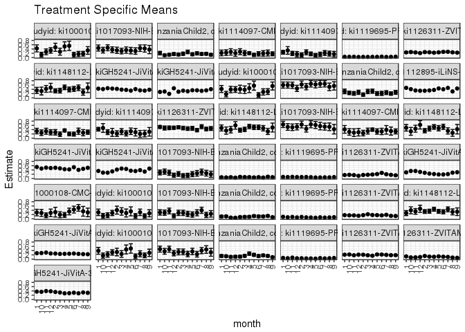

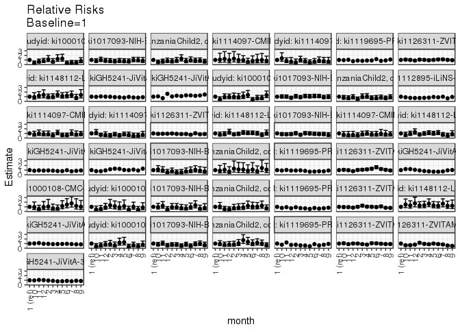

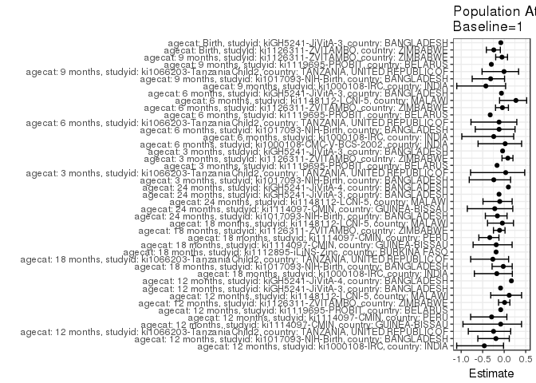

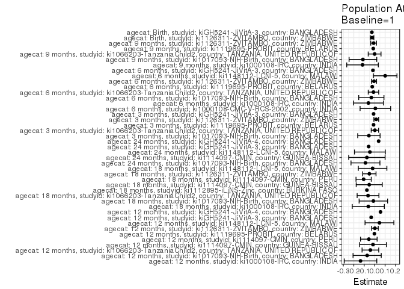

## Results Table

### Parameter: TSM

| agecat | studyid | country | intervention_level | baseline_level | estimate | ci_lower | ci_upper |
| --- | --- | --- | --- | --- | --- | --- | --- |
| Birth | ki1126311-ZVITAMBO | ZIMBABWE | 1 | NA | 0.1287202 | 0.1108156 | 0.1466249 |
| Birth | ki1126311-ZVITAMBO | ZIMBABWE | 2 | NA | 0.1486486 | 0.1269856 | 0.1703117 |
| Birth | ki1126311-ZVITAMBO | ZIMBABWE | 3 | NA | 0.1192982 | 0.1004816 | 0.1381149 |
| Birth | ki1126311-ZVITAMBO | ZIMBABWE | 4 | NA | 0.1102284 | 0.0908849 | 0.1295719 |
| Birth | ki1126311-ZVITAMBO | ZIMBABWE | 5 | NA | 0.1290000 | 0.1082237 | 0.1497763 |
| Birth | ki1126311-ZVITAMBO | ZIMBABWE | 6 | NA | 0.1139576 | 0.0954462 | 0.1324690 |
| Birth | ki1126311-ZVITAMBO | ZIMBABWE | 7 | NA | 0.1028912 | 0.0855263 | 0.1202560 |
| Birth | ki1126311-ZVITAMBO | ZIMBABWE | 8 | NA | 0.0742251 | 0.0595512 | 0.0888991 |
| Birth | ki1126311-ZVITAMBO | ZIMBABWE | 9 | NA | 0.0632140 | 0.0500509 | 0.0763771 |
| Birth | ki1126311-ZVITAMBO | ZIMBABWE | 10 | NA | 0.0815739 | 0.0649540 | 0.0981938 |
| Birth | ki1126311-ZVITAMBO | ZIMBABWE | 11 | NA | 0.0837743 | 0.0676487 | 0.0998998 |
| Birth | ki1126311-ZVITAMBO | ZIMBABWE | 12 | NA | 0.0988048 | 0.0822950 | 0.1153145 |
| Birth | kiGH5241-JiVitA-3 | BANGLADESH | 1 | NA | 0.3680258 | NA | NA |
| Birth | kiGH5241-JiVitA-3 | BANGLADESH | 2 | NA | 0.3497942 | NA | NA |
| Birth | kiGH5241-JiVitA-3 | BANGLADESH | 3 | NA | 0.3259669 | NA | NA |
| Birth | kiGH5241-JiVitA-3 | BANGLADESH | 4 | NA | 0.2885196 | NA | NA |
| Birth | kiGH5241-JiVitA-3 | BANGLADESH | 5 | NA | 0.2940000 | NA | NA |
| Birth | kiGH5241-JiVitA-3 | BANGLADESH | 6 | NA | 0.3161034 | NA | NA |
| Birth | kiGH5241-JiVitA-3 | BANGLADESH | 7 | NA | 0.2897727 | NA | NA |
| Birth | kiGH5241-JiVitA-3 | BANGLADESH | 8 | NA | 0.3299101 | NA | NA |
| Birth | kiGH5241-JiVitA-3 | BANGLADESH | 9 | NA | 0.3113402 | NA | NA |
| Birth | kiGH5241-JiVitA-3 | BANGLADESH | 10 | NA | 0.3576779 | NA | NA |
| Birth | kiGH5241-JiVitA-3 | BANGLADESH | 11 | NA | 0.3939394 | NA | NA |
| Birth | kiGH5241-JiVitA-3 | BANGLADESH | 12 | NA | 0.3820537 | NA | NA |
| 3 months | ki1017093-NIH-Birth | BANGLADESH | 1 | NA | 0.2833333 | 0.1692135 | 0.3974532 |
| 3 months | ki1017093-NIH-Birth | BANGLADESH | 2 | NA | 0.2115385 | 0.1004388 | 0.3226381 |
| 3 months | ki1017093-NIH-Birth | BANGLADESH | 3 | NA | 0.1346154 | 0.0417659 | 0.2274649 |
| 3 months | ki1017093-NIH-Birth | BANGLADESH | 4 | NA | 0.1458333 | 0.0459004 | 0.2457662 |
| 3 months | ki1017093-NIH-Birth | BANGLADESH | 5 | NA | 0.2045455 | 0.0852550 | 0.3238359 |
| 3 months | ki1017093-NIH-Birth | BANGLADESH | 6 | NA | 0.2439024 | 0.1123392 | 0.3754656 |

[output cut: 486 more lines]

### Parameter: E(Y)

| agecat | studyid | country | intervention_level | baseline_level | estimate | ci_lower | ci_upper |
| --- | --- | --- | --- | --- | --- | --- | --- |
| Birth | ki1126311-ZVITAMBO | ZIMBABWE | NA | NA | 0.1036581 | 0.0985732 | 0.1087430 |
| Birth | kiGH5241-JiVitA-3 | BANGLADESH | NA | NA | 0.3412682 | NA | NA |
| 3 months | ki1017093-NIH-Birth | BANGLADESH | NA | NA | 0.2280702 | 0.1935943 | 0.2625460 |
| 3 months | ki1066203-TanzaniaChild2 | TANZANIA, UNITED REPUBLIC OF | NA | NA | 0.0597731 | 0.0500657 | 0.0694806 |
| 3 months | ki1119695-PROBIT | BELARUS | NA | NA | 0.0628025 | NA | NA |
| 3 months | ki1126311-ZVITAMBO | ZIMBABWE | NA | NA | 0.1780419 | 0.1702125 | 0.1858712 |
| 3 months | kiGH5241-JiVitA-3 | BANGLADESH | NA | NA | 0.2767980 | NA | NA |
| 6 months | ki1000108-CMC-V-BCS-2002 | INDIA | NA | NA | 0.3008130 | 0.2539566 | 0.3476694 |
| 6 months | ki1000108-IRC | INDIA | NA | NA | 0.2457002 | 0.2038248 | 0.2875757 |
| 6 months | ki1017093-NIH-Birth | BANGLADESH | NA | NA | 0.2681564 | 0.2306532 | 0.3056597 |
| 6 months | ki1066203-TanzaniaChild2 | TANZANIA, UNITED REPUBLIC OF | NA | NA | 0.0970922 | 0.0842059 | 0.1099785 |
| 6 months | ki1119695-PROBIT | BELARUS | NA | NA | 0.0713633 | NA | NA |
| 6 months | ki1126311-ZVITAMBO | ZIMBABWE | NA | NA | 0.1660829 | 0.1580659 | 0.1740998 |
| 6 months | ki1148112-LCNI-5 | MALAWI | NA | NA | 0.3682956 | 0.3356382 | 0.4009530 |
| 6 months | kiGH5241-JiVitA-3 | BANGLADESH | NA | NA | 0.2618103 | NA | NA |
| 9 months | ki1000108-IRC | INDIA | NA | NA | 0.2727273 | 0.2294063 | 0.3160482 |
| 9 months | ki1017093-NIH-Birth | BANGLADESH | NA | NA | 0.3570020 | 0.3152562 | 0.3987478 |
| 9 months | ki1066203-TanzaniaChild2 | TANZANIA, UNITED REPUBLIC OF | NA | NA | 0.1482103 | 0.1317366 | 0.1646840 |
| 9 months | ki1119695-PROBIT | BELARUS | NA | NA | 0.0449018 | NA | NA |
| 9 months | ki1126311-ZVITAMBO | ZIMBABWE | NA | NA | 0.1978840 | 0.1889592 | 0.2068088 |
| 12 months | ki1000108-IRC | INDIA | NA | NA | 0.2931034 | 0.2487723 | 0.3374346 |
| 12 months | ki1017093-NIH-Birth | BANGLADESH | NA | NA | 0.3747454 | 0.3318860 | 0.4176049 |
| 12 months | ki1066203-TanzaniaChild2 | TANZANIA, UNITED REPUBLIC OF | NA | NA | 0.1655125 | 0.1463373 | 0.1846877 |
| 12 months | ki1114097-CMIN | GUINEA-BISSAU | NA | NA | 0.2000000 | 0.1684890 | 0.2315110 |
| 12 months | ki1114097-CMIN | PERU | NA | NA | 0.1913478 | 0.1598728 | 0.2228227 |
| 12 months | ki1119695-PROBIT | BELARUS | NA | NA | 0.0341262 | NA | NA |
| 12 months | ki1126311-ZVITAMBO | ZIMBABWE | NA | NA | 0.2442827 | 0.2340199 | 0.2545456 |
| 12 months | ki1148112-LCNI-5 | MALAWI | NA | NA | 0.3945687 | 0.3562508 | 0.4328866 |
| 12 months | kiGH5241-JiVitA-3 | BANGLADESH | NA | NA | 0.3967814 | NA | NA |
| 12 months | kiGH5241-JiVitA-4 | BANGLADESH | NA | NA | 0.3335944 | NA | NA |
| 18 months | ki1000108-IRC | INDIA | NA | NA | 0.3555556 | 0.3088785 | 0.4022327 |
| 18 months | ki1017093-NIH-Birth | BANGLADESH | NA | NA | 0.5874730 | 0.5425832 | 0.6323628 |
| 18 months | ki1066203-TanzaniaChild2 | TANZANIA, UNITED REPUBLIC OF | NA | NA | 0.2408163 | 0.2140325 | 0.2676002 |
| 18 months | ki1112895-iLiNS-Zinc | BURKINA FASO | NA | NA | 0.3944354 | NA | NA |
| 18 months | ki1114097-CMIN | GUINEA-BISSAU | NA | NA | 0.2811671 | 0.2490566 | 0.3132776 |
| 18 months | ki1114097-CMIN | PERU | NA | NA | 0.3149284 | 0.2737175 | 0.3561393 |
| 18 months | ki1126311-ZVITAMBO | ZIMBABWE | NA | NA | 0.4756598 | 0.4519478 | 0.4993718 |
| 18 months | ki1148112-LCNI-5 | MALAWI | NA | NA | 0.4593103 | 0.4230104 | 0.4956103 |
| 24 months | ki1017093-NIH-Birth | BANGLADESH | NA | NA | 0.5547786 | 0.5076945 | 0.6018626 |
| 24 months | ki1114097-CMIN | GUINEA-BISSAU | NA | NA | 0.3393829 | 0.2998111 | 0.3789548 |
| 24 months | ki1148112-LCNI-5 | MALAWI | NA | NA | 0.4421416 | 0.4016536 | 0.4826297 |
| 24 months | kiGH5241-JiVitA-3 | BANGLADESH | NA | NA | 0.4814815 | NA | NA |
| 24 months | kiGH5241-JiVitA-4 | BANGLADESH | NA | NA | 0.3908873 | NA | NA |

### Parameter: RR

| agecat | studyid | country | intervention_level | baseline_level | estimate | ci_lower | ci_upper |
| --- | --- | --- | --- | --- | --- | --- | --- |
| Birth | ki1126311-ZVITAMBO | ZIMBABWE | 1 | 1 | 1.0000000 | 1.0000000 | 1.0000000 |
| Birth | ki1126311-ZVITAMBO | ZIMBABWE | 2 | 1 | 1.1548196 | 0.9441066 | 1.4125610 |
| Birth | ki1126311-ZVITAMBO | ZIMBABWE | 3 | 1 | 0.9268026 | 0.7510259 | 1.1437195 |
| Birth | ki1126311-ZVITAMBO | ZIMBABWE | 4 | 1 | 0.8563409 | 0.6845361 | 1.0712652 |
| Birth | ki1126311-ZVITAMBO | ZIMBABWE | 5 | 1 | 1.0021734 | 0.8100680 | 1.2398361 |
| Birth | ki1126311-ZVITAMBO | ZIMBABWE | 6 | 1 | 0.8853122 | 0.7148568 | 1.0964121 |
| Birth | ki1126311-ZVITAMBO | ZIMBABWE | 7 | 1 | 0.7993394 | 0.6423171 | 0.9947477 |
| Birth | ki1126311-ZVITAMBO | ZIMBABWE | 8 | 1 | 0.5766391 | 0.4528181 | 0.7343183 |
| Birth | ki1126311-ZVITAMBO | ZIMBABWE | 9 | 1 | 0.4910962 | 0.3823070 | 0.6308424 |
| Birth | ki1126311-ZVITAMBO | ZIMBABWE | 10 | 1 | 0.6337302 | 0.4951837 | 0.8110403 |
| Birth | ki1126311-ZVITAMBO | ZIMBABWE | 11 | 1 | 0.6508242 | 0.5132450 | 0.8252826 |
| Birth | ki1126311-ZVITAMBO | ZIMBABWE | 12 | 1 | 0.7675932 | 0.6176032 | 0.9540095 |
| Birth | kiGH5241-JiVitA-3 | BANGLADESH | 1 | 1 | 1.0000000 | NA | NA |
| Birth | kiGH5241-JiVitA-3 | BANGLADESH | 2 | 1 | 0.9504613 | NA | NA |
| Birth | kiGH5241-JiVitA-3 | BANGLADESH | 3 | 1 | 0.8857175 | NA | NA |
| Birth | kiGH5241-JiVitA-3 | BANGLADESH | 4 | 1 | 0.7839659 | NA | NA |
| Birth | kiGH5241-JiVitA-3 | BANGLADESH | 5 | 1 | 0.7988571 | NA | NA |
| Birth | kiGH5241-JiVitA-3 | BANGLADESH | 6 | 1 | 0.8589165 | NA | NA |
| Birth | kiGH5241-JiVitA-3 | BANGLADESH | 7 | 1 | 0.7873708 | NA | NA |
| Birth | kiGH5241-JiVitA-3 | BANGLADESH | 8 | 1 | 0.8964322 | NA | NA |
| Birth | kiGH5241-JiVitA-3 | BANGLADESH | 9 | 1 | 0.8459740 | NA | NA |
| Birth | kiGH5241-JiVitA-3 | BANGLADESH | 10 | 1 | 0.9718828 | NA | NA |
| Birth | kiGH5241-JiVitA-3 | BANGLADESH | 11 | 1 | 1.0704126 | NA | NA |
| Birth | kiGH5241-JiVitA-3 | BANGLADESH | 12 | 1 | 1.0381166 | NA | NA |
| 3 months | ki1017093-NIH-Birth | BANGLADESH | 1 | 1 | 1.0000000 | 1.0000000 | 1.0000000 |
| 3 months | ki1017093-NIH-Birth | BANGLADESH | 2 | 1 | 0.7466063 | 0.3851665 | 1.4472209 |
| 3 months | ki1017093-NIH-Birth | BANGLADESH | 3 | 1 | 0.4751131 | 0.2137535 | 1.0560411 |
| 3 months | ki1017093-NIH-Birth | BANGLADESH | 4 | 1 | 0.5147059 | 0.2324642 | 1.1396257 |
| 3 months | ki1017093-NIH-Birth | BANGLADESH | 5 | 1 | 0.7219251 | 0.3553689 | 1.4665773 |
| 3 months | ki1017093-NIH-Birth | BANGLADESH | 6 | 1 | 0.8608321 | 0.4390903 | 1.6876527 |

[output cut: 486 more lines]

### Parameter: PAR

| agecat | studyid | country | intervention_level | baseline_level | estimate | ci_lower | ci_upper |
| --- | --- | --- | --- | --- | --- | --- | --- |
| Birth | ki1126311-ZVITAMBO | ZIMBABWE | 1 | NA | -0.0250621 | -0.0419148 | -0.0082094 |
| Birth | kiGH5241-JiVitA-3 | BANGLADESH | 1 | NA | -0.0267575 | NA | NA |
| 3 months | ki1017093-NIH-Birth | BANGLADESH | 1 | NA | -0.0552632 | -0.1623620 | 0.0518357 |
| 3 months | ki1066203-TanzaniaChild2 | TANZANIA, UNITED REPUBLIC OF | 1 | NA | 0.0020808 | -0.0332916 | 0.0374532 |
| 3 months | ki1119695-PROBIT | BELARUS | 1 | NA | -0.0104648 | NA | NA |
| 3 months | ki1126311-ZVITAMBO | ZIMBABWE | 1 | NA | 0.0151508 | -0.0074808 | 0.0377824 |
| 3 months | kiGH5241-JiVitA-3 | BANGLADESH | 1 | NA | -0.0102791 | NA | NA |
| 6 months | ki1000108-CMC-V-BCS-2002 | INDIA | 1 | NA | 0.0066954 | -0.1395296 | 0.1529203 |
| 6 months | ki1000108-IRC | INDIA | 1 | NA | -0.0598553 | -0.2028108 | 0.0831002 |
| 6 months | ki1017093-NIH-Birth | BANGLADESH | 1 | NA | -0.0318436 | -0.1525110 | 0.0888238 |
| 6 months | ki1066203-TanzaniaChild2 | TANZANIA, UNITED REPUBLIC OF | 1 | NA | -0.0116035 | -0.0615755 | 0.0383685 |
| 6 months | ki1119695-PROBIT | BELARUS | 1 | NA | -0.0232041 | NA | NA |
| 6 months | ki1126311-ZVITAMBO | ZIMBABWE | 1 | NA | -0.0068027 | -0.0315992 | 0.0179937 |
| 6 months | ki1148112-LCNI-5 | MALAWI | 1 | NA | 0.1004384 | -0.0124209 | 0.2132978 |
| 6 months | kiGH5241-JiVitA-3 | BANGLADESH | 1 | NA | -0.0167082 | NA | NA |
| 9 months | ki1000108-IRC | INDIA | 1 | NA | -0.1161616 | -0.2671628 | 0.0348396 |
| 9 months | ki1017093-NIH-Birth | BANGLADESH | 1 | NA | -0.1123858 | -0.2447695 | 0.0199979 |
| 9 months | ki1066203-TanzaniaChild2 | TANZANIA, UNITED REPUBLIC OF | 1 | NA | -0.0005500 | -0.0617826 | 0.0606825 |
| 9 months | ki1119695-PROBIT | BELARUS | 1 | NA | -0.0134136 | NA | NA |
| 9 months | ki1126311-ZVITAMBO | ZIMBABWE | 1 | NA | -0.0101784 | -0.0373352 | 0.0169784 |
| 12 months | ki1000108-IRC | INDIA | 1 | NA | -0.1354680 | -0.2912399 | 0.0203039 |
| 12 months | ki1017093-NIH-Birth | BANGLADESH | 1 | NA | -0.0720631 | -0.2069879 | 0.0628617 |
| 12 months | ki1066203-TanzaniaChild2 | TANZANIA, UNITED REPUBLIC OF | 1 | NA | -0.0410093 | -0.1206482 | 0.0386296 |
| 12 months | ki1114097-CMIN | GUINEA-BISSAU | 1 | NA | -0.0162162 | -0.1447174 | 0.1122850 |
| 12 months | ki1114097-CMIN | PERU | 1 | NA | -0.0559641 | -0.1353929 | 0.0234648 |
| 12 months | ki1119695-PROBIT | BELARUS | 1 | NA | -0.0027591 | NA | NA |
| 12 months | ki1126311-ZVITAMBO | ZIMBABWE | 1 | NA | 0.0022956 | -0.0297265 | 0.0343176 |
| 12 months | ki1148112-LCNI-5 | MALAWI | 1 | NA | 0.0457315 | -0.0921132 | 0.1835762 |
| 12 months | kiGH5241-JiVitA-3 | BANGLADESH | 1 | NA | -0.0334321 | NA | NA |
| 12 months | kiGH5241-JiVitA-4 | BANGLADESH | 1 | NA | 0.0558166 | NA | NA |
| 18 months | ki1000108-IRC | INDIA | 1 | NA | -0.0611111 | -0.2145924 | 0.0923702 |
| 18 months | ki1017093-NIH-Birth | BANGLADESH | 1 | NA | -0.0125270 | -0.1487477 | 0.1236937 |
| 18 months | ki1066203-TanzaniaChild2 | TANZANIA, UNITED REPUBLIC OF | 1 | NA | -0.0635315 | -0.1677191 | 0.0406561 |
| 18 months | ki1112895-iLiNS-Zinc | BURKINA FASO | 1 | NA | -0.0743146 | NA | NA |
| 18 months | ki1114097-CMIN | GUINEA-BISSAU | 1 | NA | -0.0521662 | -0.1767630 | 0.0724305 |
| 18 months | ki1114097-CMIN | PERU | 1 | NA | -0.1057065 | -0.1785537 | -0.0328593 |
| 18 months | ki1126311-ZVITAMBO | ZIMBABWE | 1 | NA | -0.0509102 | -0.1146857 | 0.0128652 |
| 18 months | ki1148112-LCNI-5 | MALAWI | 1 | NA | -0.0198563 | -0.1564938 | 0.1167812 |
| 24 months | ki1017093-NIH-Birth | BANGLADESH | 1 | NA | -0.0880786 | -0.2264399 | 0.0502827 |
| 24 months | ki1114097-CMIN | GUINEA-BISSAU | 1 | NA | -0.0744102 | -0.2486730 | 0.0998527 |
| 24 months | ki1148112-LCNI-5 | MALAWI | 1 | NA | -0.0456633 | -0.1932041 | 0.1018776 |
| 24 months | kiGH5241-JiVitA-3 | BANGLADESH | 1 | NA | -0.0576247 | NA | NA |
| 24 months | kiGH5241-JiVitA-4 | BANGLADESH | 1 | NA | 0.0379461 | NA | NA |

### Parameter: PAF

| agecat | studyid | country | intervention_level | baseline_level | estimate | ci_lower | ci_upper |
| --- | --- | --- | --- | --- | --- | --- | --- |
| Birth | ki1126311-ZVITAMBO | ZIMBABWE | 1 | NA | -0.2417770 | -0.4151278 | -0.0896613 |
| Birth | kiGH5241-JiVitA-3 | BANGLADESH | 1 | NA | -0.0784062 | NA | NA |
| 3 months | ki1017093-NIH-Birth | BANGLADESH | 1 | NA | -0.2423077 | -0.8124161 | 0.1484691 |
| 3 months | ki1066203-TanzaniaChild2 | TANZANIA, UNITED REPUBLIC OF | 1 | NA | 0.0348119 | -0.7818718 | 0.4771857 |
| 3 months | ki1119695-PROBIT | BELARUS | 1 | NA | -0.1666301 | NA | NA |
| 3 months | ki1126311-ZVITAMBO | ZIMBABWE | 1 | NA | 0.0850970 | -0.0512328 | 0.2037467 |
| 3 months | kiGH5241-JiVitA-3 | BANGLADESH | 1 | NA | -0.0371359 | NA | NA |
| 6 months | ki1000108-CMC-V-BCS-2002 | INDIA | 1 | NA | 0.0222576 | -0.6074578 | 0.4052843 |
| 6 months | ki1000108-IRC | INDIA | 1 | NA | -0.2436111 | -0.9850568 | 0.2208946 |
| 6 months | ki1017093-NIH-Birth | BANGLADESH | 1 | NA | -0.1187500 | -0.6726134 | 0.2517090 |
| 6 months | ki1066203-TanzaniaChild2 | TANZANIA, UNITED REPUBLIC OF | 1 | NA | -0.1195100 | -0.7726362 | 0.2929724 |
| 6 months | ki1119695-PROBIT | BELARUS | 1 | NA | -0.3251538 | NA | NA |
| 6 months | ki1126311-ZVITAMBO | ZIMBABWE | 1 | NA | -0.0409597 | -0.2014903 | 0.0981224 |
| 6 months | ki1148112-LCNI-5 | MALAWI | 1 | NA | 0.2727115 | -0.1081699 | 0.5226828 |
| 6 months | kiGH5241-JiVitA-3 | BANGLADESH | 1 | NA | -0.0638180 | NA | NA |
| 9 months | ki1000108-IRC | INDIA | 1 | NA | -0.4259259 | -1.1028874 | 0.0331081 |
| 9 months | ki1017093-NIH-Birth | BANGLADESH | 1 | NA | -0.3148044 | -0.7443137 | 0.0089452 |
| 9 months | ki1066203-TanzaniaChild2 | TANZANIA, UNITED REPUBLIC OF | 1 | NA | -0.0037112 | -0.5148599 | 0.3349641 |
| 9 months | ki1119695-PROBIT | BELARUS | 1 | NA | -0.2987311 | NA | NA |
| 9 months | ki1126311-ZVITAMBO | ZIMBABWE | 1 | NA | -0.0514362 | -0.1980201 | 0.0772124 |
| 12 months | ki1000108-IRC | INDIA | 1 | NA | -0.4621849 | -1.1044774 | -0.0159219 |
| 12 months | ki1017093-NIH-Birth | BANGLADESH | 1 | NA | -0.1922988 | -0.6130060 | 0.1186788 |
| 12 months | ki1066203-TanzaniaChild2 | TANZANIA, UNITED REPUBLIC OF | 1 | NA | -0.2477715 | -0.8342438 | 0.1511849 |
| 12 months | ki1114097-CMIN | GUINEA-BISSAU | 1 | NA | -0.0810811 | -0.9585917 | 0.4032772 |
| 12 months | ki1114097-CMIN | PERU | 1 | NA | -0.2924731 | -0.7804881 | 0.0617816 |
| 12 months | ki1119695-PROBIT | BELARUS | 1 | NA | -0.0808495 | NA | NA |
| 12 months | ki1126311-ZVITAMBO | ZIMBABWE | 1 | NA | 0.0093972 | -0.1307574 | 0.1321799 |
| 12 months | ki1148112-LCNI-5 | MALAWI | 1 | NA | 0.1159025 | -0.3125847 | 0.4045120 |
| 12 months | kiGH5241-JiVitA-3 | BANGLADESH | 1 | NA | -0.0842583 | NA | NA |
| 12 months | kiGH5241-JiVitA-4 | BANGLADESH | 1 | NA | 0.1673187 | NA | NA |
| 18 months | ki1000108-IRC | INDIA | 1 | NA | -0.1718750 | -0.6940254 | 0.1893327 |
| 18 months | ki1017093-NIH-Birth | BANGLADESH | 1 | NA | -0.0213235 | -0.2816453 | 0.1861229 |
| 18 months | ki1066203-TanzaniaChild2 | TANZANIA, UNITED REPUBLIC OF | 1 | NA | -0.2638172 | -0.7794625 | 0.1024065 |
| 18 months | ki1112895-iLiNS-Zinc | BURKINA FASO | 1 | NA | -0.1884077 | NA | NA |
| 18 months | ki1114097-CMIN | GUINEA-BISSAU | 1 | NA | -0.1855346 | -0.7228036 | 0.1841831 |
| 18 months | ki1114097-CMIN | PERU | 1 | NA | -0.3356524 | -0.5893326 | -0.1224632 |
| 18 months | ki1126311-ZVITAMBO | ZIMBABWE | 1 | NA | -0.1070307 | -0.2496868 | 0.0193406 |
| 18 months | ki1148112-LCNI-5 | MALAWI | 1 | NA | -0.0432307 | -0.3874859 | 0.2156098 |
| 24 months | ki1017093-NIH-Birth | BANGLADESH | 1 | NA | -0.1587635 | -0.4378866 | 0.0661761 |
| 24 months | ki1114097-CMIN | GUINEA-BISSAU | 1 | NA | -0.2192513 | -0.8580064 | 0.1999092 |
| 24 months | ki1148112-LCNI-5 | MALAWI | 1 | NA | -0.1032774 | -0.4930707 | 0.1847532 |
| 24 months | kiGH5241-JiVitA-3 | BANGLADESH | 1 | NA | -0.1196820 | NA | NA |
| 24 months | kiGH5241-JiVitA-4 | BANGLADESH | 1 | NA | 0.0970769 | NA | NA |